# Logistic Regression - Week 12, Day 1

Author

Hector Gavilanes

**Recall the Titanic data from lecture. Use it to answer the following questions.**

```r
# clear environment
rm(list = ls())
# load data
data <- as_tibble(gsheet2tbl("https://docs.google.com/spreadsheets/d/1TrJ6jZ3hP6gQk6FvqbMrFUysEUEqle7XfuLnAkZsHYI/edit"))
```

**1. Model survival as a function of age (*Age*), the number of siblings and/or spouses (*SibSp*), the number of parents or children (*Parch*), the class of ticket (*Pclass*), and amount paid for ticket (*Fare*).**

```r
m1 <- glm(data$Survived ~ data$Age + data$SibSp + data$Parch + data$Pclass + data$Fare,
          family = binomial)
summary(m1)
```

```
Call:
glm(formula = data$Survived ~ data$Age + data$SibSp + data$Parch +
    data$Pclass + data$Fare, family = binomial)

Deviance Residuals:
    Min       1Q   Median       3Q      Max
-2.4155  -0.8355  -0.6207   0.9942   2.4047

Coefficients:
             Estimate Std. Error z value Pr(>|z|)
(Intercept)  3.401026   0.505176   6.732 1.67e-11 ***
data$Age    -0.044566   0.007210  -6.181 6.36e-10 ***
data$SibSp  -0.292273   0.106079  -2.755  0.00586 **
data$Parch   0.247881   0.109075   2.273  0.02305 *
data$Pclass -1.153008   0.145943  -7.900 2.78e-15 ***
data$Fare    0.003294   0.002537   1.299  0.19402
---
Signif. codes:  0 '***' 0.001 '**' 0.01 '*' 0.05 '.' 0.1 ' ' 1

(Dispersion parameter for binomial family taken to be 1)

    Null deviance: 964.52  on 713  degrees of freedom
Residual deviance: 815.18  on 708  degrees of freedom
  (177 observations deleted due to missingness)
AIC: 827.18

Number of Fisher Scoring iterations: 4
```

**1a. Report the model.**

```r
m1_coeff <- coefficients(m1)
```

$$\ln \left( \frac{\hat{\pi}}{1-\hat{\pi}} \right) = 3.401 -0.045 \text{ Age} -0.292 \text{ Sibling \& Spouse} + 0.248 \text{ Parents \& Children} -1.153 \text{ Class} + 0.003 \text{ Fare}$$
**1b. Which, if any, are significant predictors of survival? The full hypothesis test is not needed, but you must provide statistical justification.**

```r
significant <- coef(summary(m1))[,'Pr(>|z|)']
significant < 0.05
```

```
(Intercept)    data$Age  data$SibSp  data$Parch data$Pclass   data$Fare
       TRUE        TRUE        TRUE        TRUE        TRUE       FALSE
```

```r
round(significant[2:5], 3)
```

```
   data$Age  data$SibSp  data$Parch data$Pclass
      0.000       0.006       0.023       0.000
```

```r
non_significant <- coef(summary(m1))[,'Pr(>|z|)']
non_significant > 0.05
```

```
(Intercept)    data$Age  data$SibSp  data$Parch data$Pclass   data$Fare
      FALSE       FALSE       FALSE       FALSE       FALSE        TRUE
```

```r
round(non_significant, 3)
```

```
(Intercept)    data$Age  data$SibSp  data$Parch data$Pclass   data$Fare
      0.000       0.000       0.006       0.023       0.000       0.194
```

- Age (p < 0.001), Siblings & Spouses (p = 0.006), Parents & Children (p = 0.023), and Passenger Class (p < 0.001) are significant predictors of survival.
- Fare (0.194) is not a significant predictor of survival.

**1c. Find the odds ratios and corresponding 95% confidence intervals.**

```r
# get odd ratios
round(exp(coefficients(m1)[-1]), 3)
```

```
   data$Age  data$SibSp  data$Parch data$Pclass   data$Fare
      0.956       0.747       1.281       0.316       1.003
```

```r
# get CI of odd ratios
round(exp(confint(m1)), 3)
```

```
             2.5 % 97.5 %
(Intercept) 11.266 81.922
data$Age     0.943  0.970
data$SibSp   0.602  0.914
data$Parch   1.030  1.584
data$Pclass  0.237  0.419
data$Fare    0.999  1.009
```

**2. Challenge! Model survival as a function of age (*Age*), the class of ticket (*Pclass*), and sex of passenger (*Sex*).**

```r
# change variables to a factor (categorical)
data$Sex <- as.factor(data$Sex)
data$Embarked <- as.factor(data$Embarked)

# check for missing values
miss_var_summary(data)
```

```
# A tibble: 12 × 3
   variable    n_miss pct_miss
   <chr>        <int>    <dbl>
 1 Cabin          687   77.1
 2 Age            177   19.9
 3 Embarked         2    0.224
 4 PassengerId      0    0
 5 Survived         0    0
 6 Pclass           0    0
 7 Name             0    0
 8 Sex              0    0
 9 SibSp            0    0
10 Parch            0    0
11 Ticket           0    0
12 Fare             0    0
```

```r
# check for unique values
sapply(data, function(x) length(unique(x)))
```

```
PassengerId    Survived      Pclass        Name         Sex         Age
        891           2           3         891           2          89
      SibSp       Parch      Ticket        Fare       Cabin    Embarked
          7           7         681         248         148           4
```

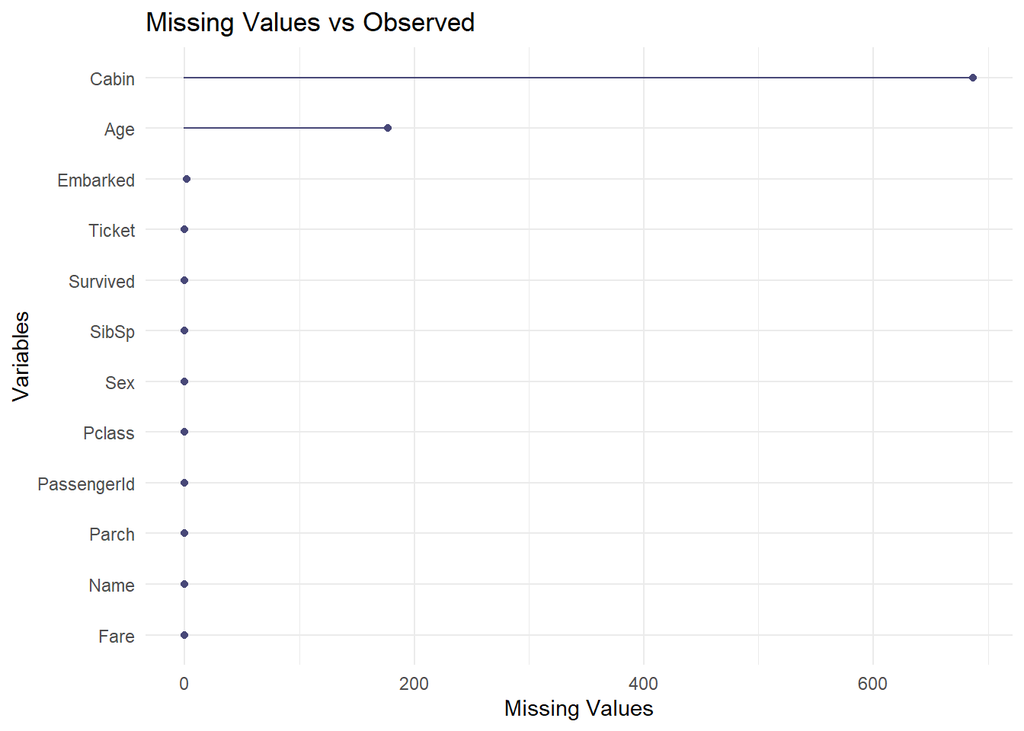

```r
# visualizing missing values
gg_miss_var(data) +
  labs(title = "Missing Values vs Observed",
       y = "Missing Values")+
  guides(colour = "none")
```

```r
# drop cabin, Passenger-ID, Name, Ticket columns
clean_data <- subset(data,select=c(2,3,5,6,7,8,10,12))

# replace missing values with mean
clean_data$Age[is.na(clean_data$Age)] <- mean(clean_data$Age,na.rm=T)

# double-check variables are factors
is.factor(clean_data$Sex)
```

```
[1] TRUE
```

```r
is.factor(clean_data$Embarked)
```

```
[1] TRUE
```

```r
# R interpretation of categorical variable
contrasts(clean_data$Sex)
```

```
       male
female    0
male      1
```

```r
# logistic regression model
m2 <- glm(Survived ~ Age + Pclass + Sex,
          data = clean_data,
          family = "binomial")
summary(m2)
```

```
Call:
glm(formula = Survived ~ Age + Pclass + Sex, family = "binomial",
    data = clean_data)

Deviance Residuals:
    Min       1Q   Median       3Q      Max
-2.6557  -0.6579  -0.4211   0.6371   2.4264

Coefficients:
             Estimate Std. Error z value Pr(>|z|)
(Intercept)  4.731956   0.449819  10.520  < 2e-16 ***
Age         -0.033427   0.007348  -4.549 5.38e-06 ***
Pclass      -1.168463   0.118941  -9.824  < 2e-16 ***
Sexmale     -2.611964   0.186609 -13.997  < 2e-16 ***
---
Signif. codes:  0 '***' 0.001 '**' 0.01 '*' 0.05 '.' 0.1 ' ' 1

(Dispersion parameter for binomial family taken to be 1)

    Null deviance: 1186.66  on 890  degrees of freedom
Residual deviance:  805.33  on 887  degrees of freedom
AIC: 813.33

Number of Fisher Scoring iterations: 5
```

**2a. Report the model.**

```r
m2_coeff <- coefficients(m2)
m2_coeff
```

```
(Intercept)         Age      Pclass     Sexmale
 4.73195642 -0.03342722 -1.16846287 -2.61196394
```

$$\ln \left( \frac{\hat{\pi}}{1-\hat{\pi}} \right) = 4.732 -0.033 \text{ Age} -1.168 \text{ Class} -2.612 \text{ Sex}$$
**2b. Which, if any, are significant predictors of survival? The full hypothesis test is not needed, but you must provide statistical justification.**

```r
significant <- coef(summary(m2))[,'Pr(>|z|)']
significant < 0.05
```

```
(Intercept)         Age      Pclass     Sexmale
       TRUE        TRUE        TRUE        TRUE
```

```r
round(significant, 3)
```

```
(Intercept)         Age      Pclass     Sexmale
          0           0           0           0
```

```r
non_significant <- coef(summary(m2))[,'Pr(>|z|)']
non_significant > 0.05
```

```
(Intercept)         Age      Pclass     Sexmale
      FALSE       FALSE       FALSE       FALSE
```

```r
round(non_significant, 3)
```

```
(Intercept)         Age      Pclass     Sexmale
          0           0           0           0
```

**2c. Find the odds ratios and corresponding 95% confidence intervals.**

```r
# get odds ratios
round(exp(coefficients(m2)[-1]), 3)
```

```
    Age  Pclass Sexmale
  0.967   0.311   0.073
```

```r
# get CI of odd ratios
exp(confint(m2))
```

```
                  2.5 %      97.5 %
(Intercept) 48.04527527 280.7160638
Age          0.95307909   0.9809661
Pclass       0.24501062   0.3907723
Sexmale      0.05051275   0.1050636
```

**2d. Provide interpretations for the odds ratios for each of the predictors in the model.**